# OE0290_ped_Picoplex_60pg_coverage_qc

Pitithat Puranachot

12/7/2020

This document shows how to perform selection of sample to be used for Panel-of-Normal selection. This include all cfDNA samples sequenced by lcWGS with Picoplex sequencing protocol. Basically, this following scripts will read genomic coverage files (in stat_coverage/*_CollectWgsMetrics.txt) and extract MEAN_COVERAGE of every sample defined in the variable pids.

1. Set path to the analysis results_per_pid path.
2. Set a variable pids to indicate which pids in the results_per_pid will be included. In this case, we consider all pids of 1LB to 5LB samples.
3. For each pids, Read CollectWgsMetrics.txt files and finally make a data frame.

```r
coverage_stat_list = list()
for (pid in pids) {
  result_per_pid_dir = paste0(pid_dir,pid,"/")

  if(dir.exists(
    ### skip sample with UMI alignment result (skip all AccelNGS samples)
    paste0(result_per_pid_dir,"alignment_umi/stat_coverage/"))){
    next

  }else {
    ### select only Picoplex samples
    pid_coverage_stat_dir =
      paste0(result_per_pid_dir,"alignment/stat_coverage/")

  }


   matrix_files =
    list.files(pid_coverage_stat_dir,
               pattern = glob2rx("^plasma*_CollectWgsMetrics.txt*"),
               full.names = TRUE)

  for (matrix_file in matrix_files) {
    sample_id =
      paste0(unlist(strsplit(basename(matrix_file),split="_"))[1:3],
             collapse = "_")
    stat_texts = read.delim(matrix_file, skip = 6,nrows = 1,sep="\t")
    stat_texts$sample_id = sample_id

    coverage_stat_list[[sample_id]] =  stat_texts
  }

}

coverage_stat_df = do.call(rbind, coverage_stat_list)
remove(coverage_stat_list)
```

This coverage_stat_df dataframe will contain the table of coverage statistic of all samples.

4. Now we plot the coverage distribution.

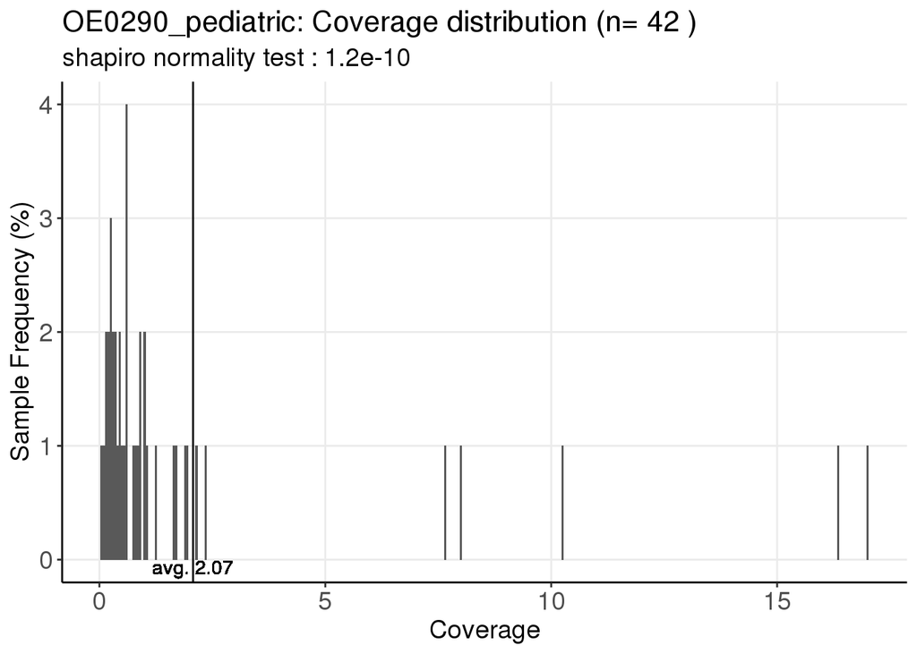

```r
plot_coverage_distribution = function(coverage_stat_df){
  test_normality = shapiro.test(coverage_stat_df$MEAN_COVERAGE)

  test_normality$p.value


  distribution_plot = ggplot(coverage_stat_df) +
    geom_histogram(aes(MEAN_COVERAGE),binwidth = 0.05) +
    theme_classic() +
    labs(x="Coverage",y="Sample Frequency (%)",
         title = paste("OE0290_pediatric: Coverage distribution (n=",
                       nrow(coverage_stat_df),")"),
         subtitle = paste0("shapiro normality test : ",
                           signif(test_normality$p.value, digit=2))) +
    theme(panel.grid.major = element_line(),
          plot.title = element_text(size = 16),
          plot.subtitle = element_text(size=14),
          axis.title = element_text(size=14),
          axis.text = element_text(size=14)) +
    geom_vline(xintercept = mean(coverage_stat_df$MEAN_COVERAGE)) +
    geom_text(x= mean(coverage_stat_df$MEAN_COVERAGE), y=0,
              label=paste0("avg. ",
                           round(mean(coverage_stat_df$MEAN_COVERAGE),2)),
              vjust = 1)
  return(distribution_plot)
}


plot_coverage_distribution(coverage_stat_df)
```

The shapiro normality test tells if the distribution of sample coverage is not normally distributed. The low p-value reject the hypothesis that the sample is normally distributed. Most of the time, the coverage distribution would show some outlier samples.

5. We remove the outlier sample that distant away from the median coverage. The coverage will be scaled around zero with mean and sd. The distance from the median is calculated and sort in descending order. The p-value of shapiro test will be calculated. The script will tell how many outliner samples will be removed to pass the shapiro p-value > 0.01.

```r
coverage_df = coverage_stat_df %>%
  select(sample_id, MEAN_COVERAGE)

coverage_df$abs_distance_from_N50 =
  abs(coverage_df$MEAN_COVERAGE - median(coverage_df$MEAN_COVERAGE))

coverage_df =
  coverage_df[order(coverage_df$abs_distance_from_N50,
                    decreasing = TRUE),]

shapiro_pvalue_list = list()
for (delete_row in seq(nrow(coverage_df))) {
  temp_coverage_df = coverage_df[seq(delete_row+1,nrow(coverage_df)),]

  if(nrow(temp_coverage_df) <=3) break

  shapiro_pvalue_list[[coverage_df$sample_id[delete_row]]] =
    shapiro.test(temp_coverage_df$MEAN_COVERAGE)$p.value
  names(shapiro_pvalue_list[[coverage_df$sample_id[delete_row]]])=
    coverage_df$sample_id[delete_row]
}

for (shapiro_pvalue in shapiro_pvalue_list) {
  if(shapiro_pvalue >= 0.01) {
    row_number = which(names(shapiro_pvalue_list) == names(shapiro_pvalue))
    # cat(which(names(shapiro_pvalue_list) == names(shapiro_pvalue)),
    #     " ",names(shapiro_pvalue)," p-value: ",shapiro_pvalue)
    break
  }
}

cat("Remove first", row_number,
    "outlier samples. The shapiro p-value :",round(shapiro_pvalue,3))
```

```
## Remove first 10 outlier samples. The shapiro p-value : 0.028
```

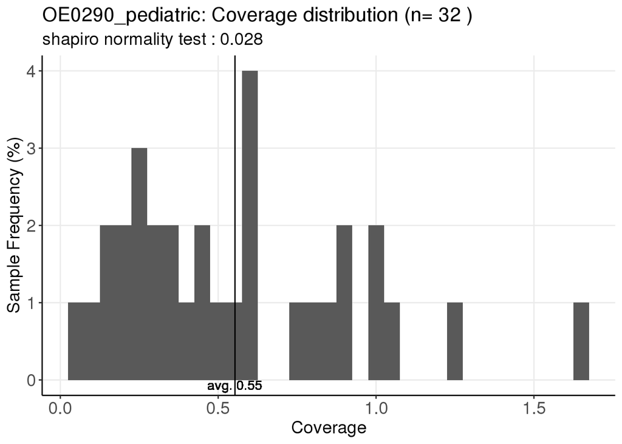

```r
norm_coverage_df = coverage_df[seq(row_number+1,
                                   nrow(coverage_df)),]

plot_coverage_distribution(norm_coverage_df)
```

```r
norm_coverage_df$zscore = (norm_coverage_df$MEAN_COVERAGE - mean(norm_coverage_df$MEAN_COVERAGE)) / sd(norm_coverage_df$MEAN_COVERAGE)


test_normality = shapiro.test(norm_coverage_df$zscore)
```

The coverage of dataset are assumed to be normally distributed. We will rescale the coverage again.

7. Rescale the coverage from the mean and sd.

```r
coverage_df$scaled_coverage = (coverage_df$MEAN_COVERAGE - mean(norm_coverage_df$MEAN_COVERAGE)) / sd(norm_coverage_df$MEAN_COVERAGE)

coverage_df = coverage_df[order(coverage_df$MEAN_COVERAGE),]
```

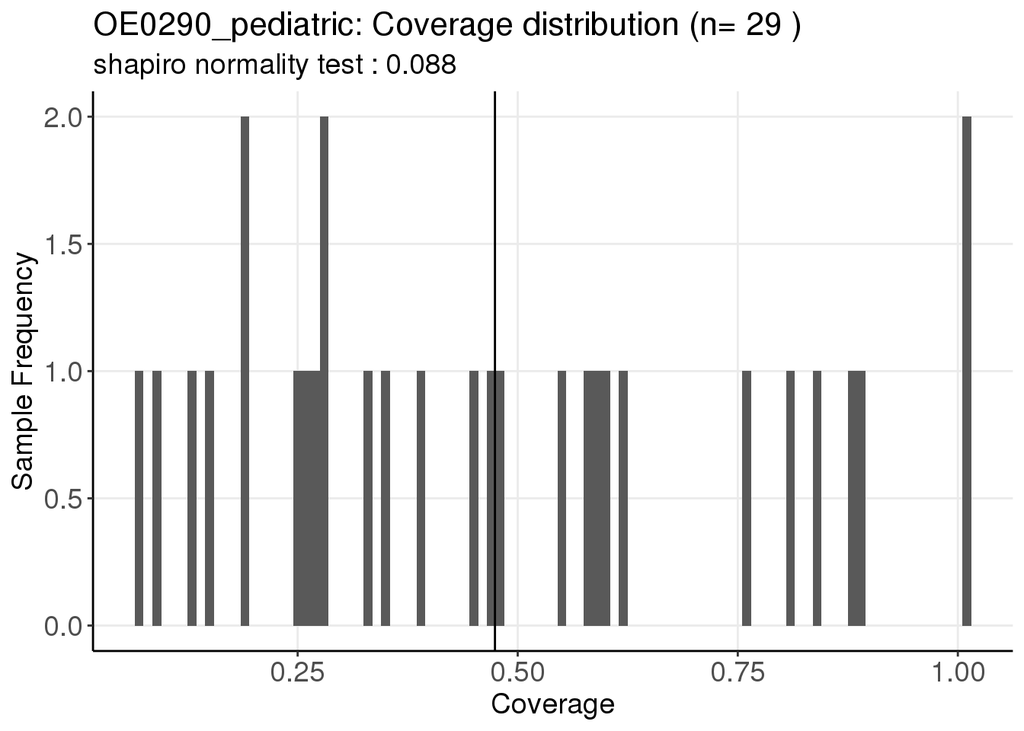

```r
coverage_df$pvalue = round(pnorm(coverage_df$scaled_coverage),3)

filtered_samples = filter(coverage_df, pvalue < 0.01 | pvalue  >0.9)  %>% select(sample_id,MEAN_COVERAGE,pvalue)


### coverage cutoff ~0.2

after_filtered_coverage_df = filter(coverage_df, pvalue >= 0.1,
                                    pvalue <=0.9)   %>% select(sample_id,MEAN_COVERAGE,pvalue)

test_normality = shapiro.test(after_filtered_coverage_df$MEAN_COVERAGE)

  # test_normality$p.value


distribution_plot = ggplot(after_filtered_coverage_df) +
    geom_histogram(aes(MEAN_COVERAGE),binwidth = 0.01) +
    theme_classic() +
    labs(x="Coverage",y="Sample Frequency",
         title = paste("OE0290_pediatric: Coverage distribution (n=",
                       nrow(after_filtered_coverage_df),")"),
         subtitle = paste0("shapiro normality test : ",
                           signif(test_normality$p.value, digit=2))) +
    theme(panel.grid.major = element_line(),
          plot.title = element_text(size = 16),
          plot.subtitle = element_text(size=14),
          axis.title = element_text(size=14),
          axis.text = element_text(size=14)) +
    geom_vline(xintercept = mean(after_filtered_coverage_df$MEAN_COVERAGE)) +
    geom_text(x= mean(coverage_stat_df$MEAN_COVERAGE), y=0,
              label=paste0("avg. ",
                           round(mean(after_filtered_coverage_df$MEAN_COVERAGE),2)),
              vjust = 1)

distribution_plot
```

```r
write.table(after_filtered_coverage_df,
            "CoverageQC_passed_nonumi_OE0290.tsv",
            sep="\t",row.names = FALSE)
```

File CoverageQC_passed_nonumi_OE0290.tsv will be used for selection of Panel-of-normal with NiPTER